# Income Salience and Sacred Values

Emma Bridger

16 December 2021

# Background and Rationale

We hypothesise that in contrast to judgments about income which are relatively well rehearsed and therefore more stable preferences that are less impacted by judgment order, participants are relatively less experienced or able to make judgments about life expectancy for different groups (in other words, they find these questions difficult). When income inequality is salient however, we hypothesise that this emphasises the secular-sacred distinction and encourages or enables participants to indicate that everyone should have equal life expectancy.  
This proposal is for an explicit test of this account. As in our previous studies, all participants will be asked to indicate what they estimate and desire life expectancy to be for two occupational groups. Participants will be randomly allocated to either a control condition (as in previous studies) or an income salience condition in which they will be provided with indicators of income differences between these two groups. We anticipate that preferences for equal life span will be significantly more likely for those participants for whom income differences have been made salient. We anticipate also that the presence of this information will make these decisions easier and quicker. We anticipate that these effects will be moderated by sacred values responding such that individuals who endorse a sacred values approach to life expectancy judgments are less impacted by the income manipulation (e.g. always endorse equal life span and are generally quicker with these responses).

# Setup

Note: If you see titles without further detail, the corresponding code and output are hidden to save space.

## Load packages

### R / package versions used

## Overview of variables

```r
names(df)
```

```
##  [1] "Ppt"               "Country"           "Income_Condition"
##  [4] "InfoCheck"         "ProfPerception"    "RoutPerception"
##  [7] "FirstClick_Perc"   "LastClick_Perc"    "SubmitTime_Perc"
## [10] "Clicks_Perc"       "ProfDesire"        "RoutDesire"
## [13] "FirstClick_Desire" "LastClick_Desire"  "SubmitTime_Desire"
## [16] "Clicks_Desire"     "Difficulty"        "issuesacrifice"
## [19] "relatemoney"       "costbenefit"       "issuesacred"
## [22] "flexible"          "age"               "gender"
## [25] "ethnicity"         "...26"
```

**Ppt** - Participant ID code  
**Country** - Whether participants currently reside in the UK or US  
**Income_Condition** - Which of the two income conditions participants were allocated to (No income/control condition, Income information condition)  
**InfoCheck** - Responses from participants in the Income condition to the information salience question  
**ProfPerception** - Perceived life expectancy for Professional workers  
**RoutPerception** - Perceived life expectancy for Routine workers  
**FirstClick_Perc** - Seconds perceived life expectancy questions were visible before first click  
**LastClick_Perc** - Seconds perceived life expectancy questions were visible before last click  
**SubmitTime_Perc** - Total seconds perceived life expectancy questions visible before next section  
**Clicks_Perc** - Total number of clicks on perceived life expectancy questions  
**ProfDesire** - Desired life expectancy for Professional workers  
**RoutDesire** - Desired life expectancy for Routine workers  
**FirstClick_Desire** - Seconds desired life expectancy questions were visible before first click  
**LastClick_Desire** - Seconds desired life expectancy questions were visible before last click  
**SubmitTime_Desire** - Total seconds desired life expectancy questions visible before next section  
**Clicks_Desire** - Total number of clicks on desired life expectancy questions  
**Difficulty** - Difficulty ratings for desired life expectancy judgments. Higher values represent higher difficulty.  
**issuessacrifice** - Agree that making these judgments is based on issues or values that we should not sacrifice, no matter what the benefits  
**relatemoney** - Agree that making these judgments is something that should not be related to money  
**costbenefit** - Agree that making these judgments is something that we can sometimes make cost-benefit analyses about [to be reverse coded]  
**issuesacred** - Agree that making these judgments is something based on issues or values that are sacred  
**flexible** - Agree that making these judgments is something that I can be flexible about if the situation requires it [to be reverse coded]  
**age** - Participant age  
**gender** - Participant gender  
**ethnicity** - Participant ethnicity

### Convert and create variables

## Data overview

There were 622 participants. Here are tables showing the number of participants from each country and income condition.

```r
table(df$Income_Condition) / ntrials
```

```
##
## Control  Income
##     311     311
```

```r
table(df$Country) / ntrials
```

```
##
##  UK  US
## 311 311
```

How many participants in the income answered the income salience question correctly (gave a response of 3)?

```r
table(df$InfoCheck) / ntrials
```

```
##
##   1   2   3   4
##   8  15 284   4
```

91.3% of participants in the income condition got the income salience question correct.

Let’s have a look at the distributions of some of the key continuous variables: perceived and desired ratios, difficulty ratings, submit time and sacred values.

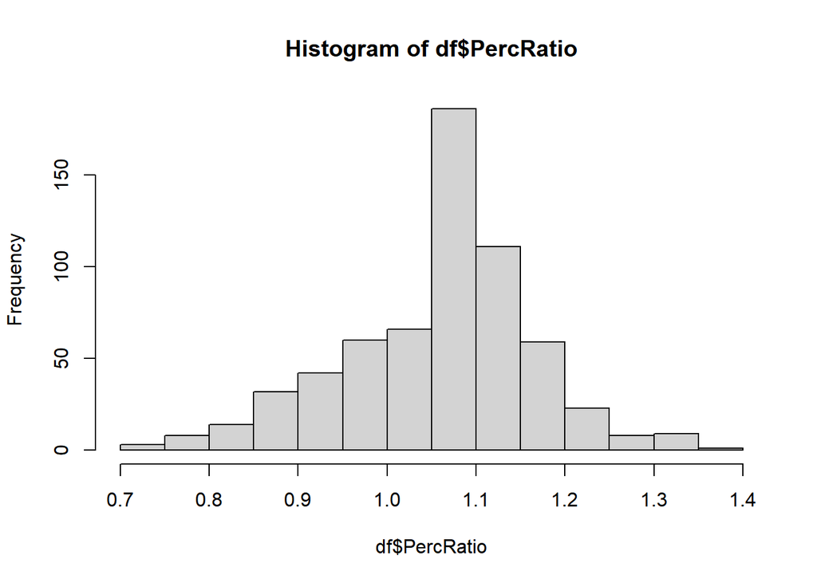

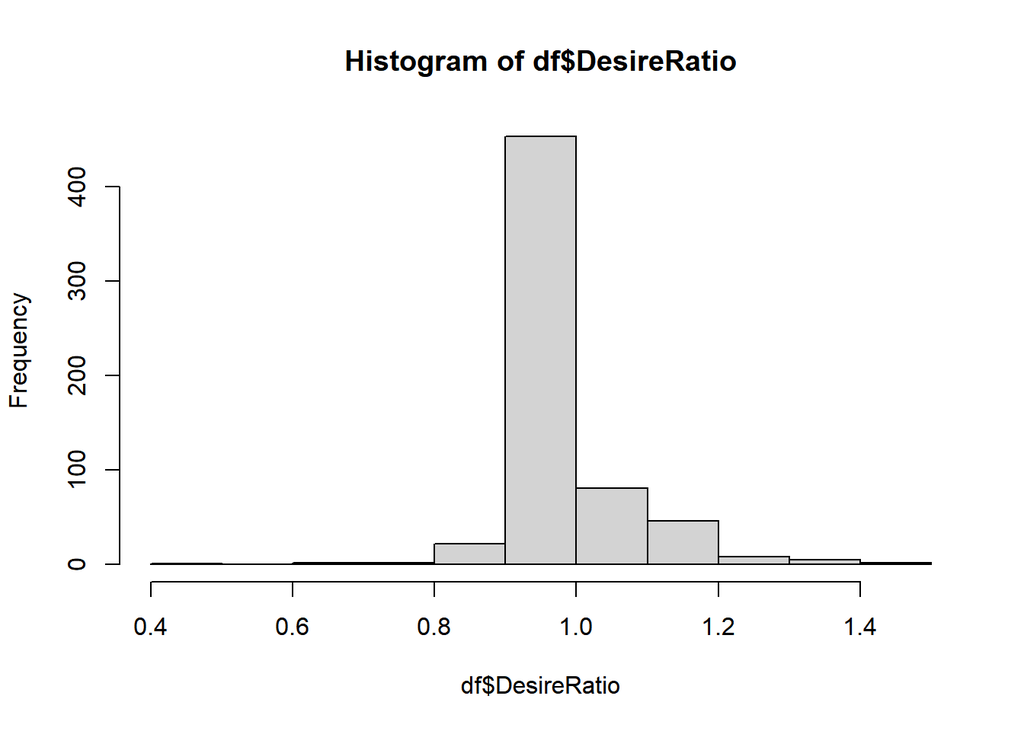

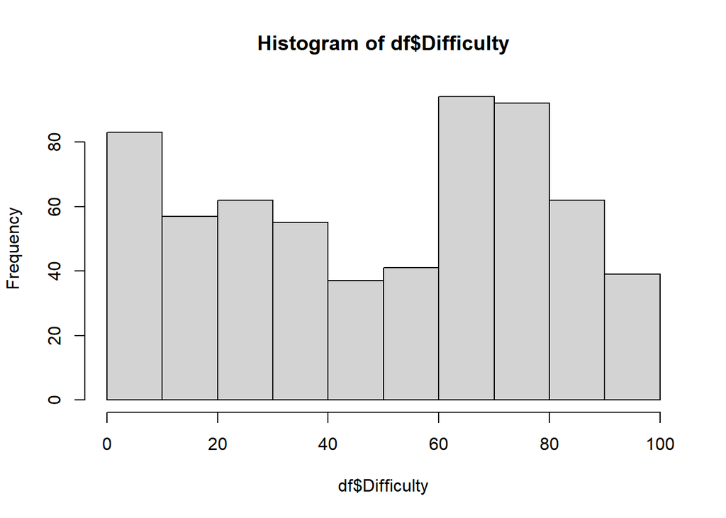

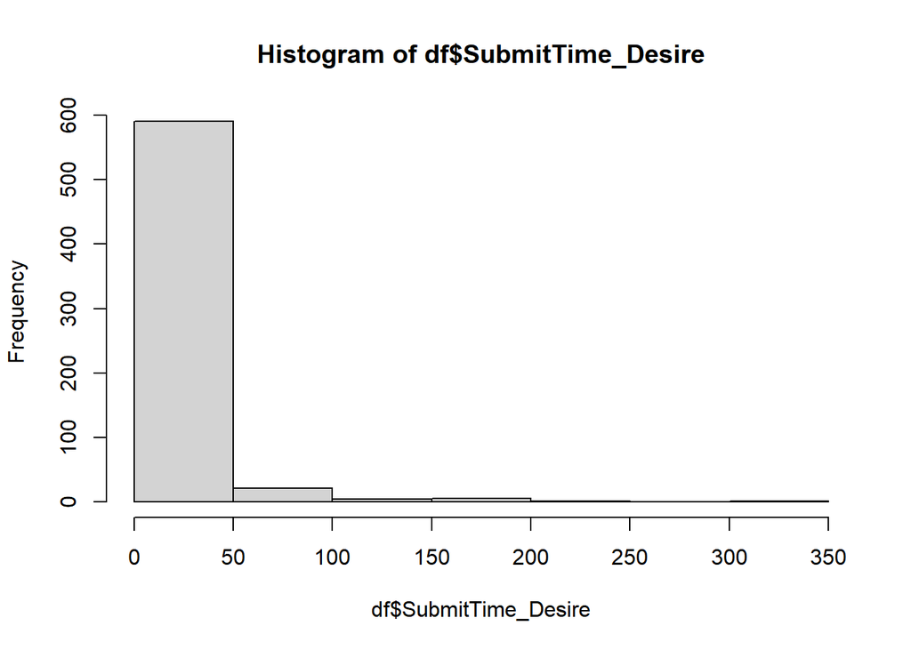

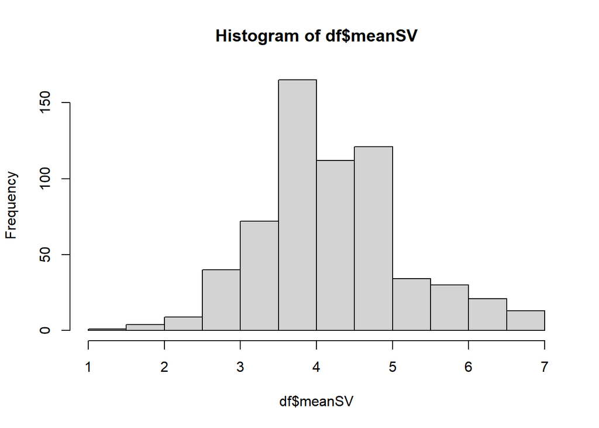

### Exclusions

Data from a 6 US participants (4 income, 2 control) and 10 UK participants (5 income, 5 control) were previously excluded on the basis that they did not provide perceptions and desired life expectancies that were interpretable as a life expectancy/numeric value.

## Data Analysis

### Question 1

Do preferences for equal life span between different occupational groups increase when income inequalities between these groups are salient?

```r
table(df$Income_Condition, df$PerceiveEquality)
```

```
##
##           perc_equality perc_inequality
##   Control            26             285
##   Income             16             295
```

```r
table(df$Income_Condition, df$DesireEquality)
```

```
##
##           choose_equality choose_inequality
##   Control             199               112
##   Income              208               103
```

63.98% of participants in the control condition choose equality  
66.88% of participants in the income condition choose equality

(Note: The rates of choosing equal life expectancy in the control condition are higher than the “before income” condition in our previous studies with this measure. UK before income = 55.8%, US before income = 48.9%)

Is the slight increase across conditions significant?

```
##
##  Pearson's Chi-squared test with Yates' continuity correction
##
## data:  table(df$Income_Condition, df$PerceiveEquality)
## X-squared = 2.0682, df = 1, p-value = 0.1504
```

```
##
##  Pearson's Chi-squared test with Yates' continuity correction
##
## data:  table(df$Income_Condition, df$DesireEquality)
## X-squared = 0.45492, df = 1, p-value = 0.5
```

The income salience manipulation does not appear to have a significant effect on proportion of participants indicating a perception or desire for equal life expectancy.

What about when other factors (age, gender, country) are included in the analysis?

```
##
## Call:
## glm(formula = DesireEquality_num ~ Income_Condition + Country +
##     age + gender, family = binomial, data = df)
##
## Deviance Residuals:
##     Min       1Q   Median       3Q      Max
## -1.7344  -1.3486   0.8126   0.9231   1.4837
##
## Coefficients:
##                         Estimate Std. Error z value Pr(>|z|)
## (Intercept)             1.555379   0.285765   5.443 5.24e-08 ***
## Income_ConditionIncome  0.095158   0.171986   0.553  0.58007
## CountryUS              -0.317402   0.175417  -1.809  0.07039 .
## age                    -0.019893   0.006221  -3.198  0.00138 **
## genderMale             -0.262865   0.198146  -1.327  0.18463
## genderNonbinary         0.298671   0.813830   0.367  0.71362
## genderPNTS             -1.417089   1.235124  -1.147  0.25125
## ---
## Signif. codes:  0 '***' 0.001 '**' 0.01 '*' 0.05 '.' 0.1 ' ' 1
##
## (Dispersion parameter for binomial family taken to be 1)
##
##     Null deviance: 799.90  on 620  degrees of freedom
## Residual deviance: 780.15  on 614  degrees of freedom
##   (1 observation deleted due to missingness)
## AIC: 794.15
##
## Number of Fisher Scoring iterations: 4
```

There is a significant effect of age on desire for equality, but no other effects. (Note: for all glm/logit models, the coefficients are raw and not yet converted to odds ratios)

What about when we limit the analysis to only those who correctly answered the income salience check?

```
##
## Call:
## glm(formula = DesireEquality_num ~ Income_Condition + Country +
##     age + gender, family = binomial, data = df_filter)
##
## Deviance Residuals:
##     Min       1Q   Median       3Q      Max
## -1.7995  -1.3225   0.7802   0.9096   1.5132
##
## Coefficients:
##                         Estimate Std. Error z value Pr(>|z|)
## (Intercept)             1.664155   0.294483   5.651 1.59e-08 ***
## Income_ConditionIncome  0.200887   0.178181   1.127 0.259558
## CountryUS              -0.357934   0.181236  -1.975 0.048273 *
## age                    -0.022218   0.006415  -3.463 0.000533 ***
## genderMale             -0.261176   0.203973  -1.280 0.200388
## genderNonbinary         0.209646   0.815055   0.257 0.797011
## genderPNTS             -1.490288   1.237312  -1.204 0.228413
## ---
## Signif. codes:  0 '***' 0.001 '**' 0.01 '*' 0.05 '.' 0.1 ' ' 1
##
## (Dispersion parameter for binomial family taken to be 1)
##
##     Null deviance: 757.56  on 593  degrees of freedom
## Residual deviance: 734.44  on 587  degrees of freedom
##   (1 observation deleted due to missingness)
## AIC: 748.44
##
## Number of Fisher Scoring iterations: 4
```

There is still no effect of the income manipulation on desire for equality. There are effects of country and age.

Is there an effect of the manipulation on perceptions of equality?

```
##
## Call:
## glm(formula = PerceiveEquality_num ~ Income_Condition + Country +
##     age + gender, family = binomial, data = df_filter)
##
## Deviance Residuals:
##     Min       1Q   Median       3Q      Max
## -0.5829  -0.4183  -0.3528  -0.3094   2.5501
##
## Coefficients:
##                         Estimate Std. Error z value Pr(>|z|)
## (Intercept)             -1.89891    0.53414  -3.555 0.000378 ***
## Income_ConditionIncome  -0.59355    0.34365  -1.727 0.084131 .
## CountryUS               -0.16341    0.33494  -0.488 0.625623
## age                     -0.01333    0.01308  -1.019 0.308155
## genderMale               0.24027    0.37790   0.636 0.524906
## genderNonbinary          0.50563    1.09396   0.462 0.643940
## genderPNTS             -12.74551  832.39435  -0.015 0.987783
## ---
## Signif. codes:  0 '***' 0.001 '**' 0.01 '*' 0.05 '.' 0.1 ' ' 1
##
## (Dispersion parameter for binomial family taken to be 1)
##
##     Null deviance: 293.08  on 593  degrees of freedom
## Residual deviance: 288.01  on 587  degrees of freedom
##   (1 observation deleted due to missingness)
## AIC: 302.01
##
## Number of Fisher Scoring iterations: 14
```

There is a marginally significant (.08) effect of the manipulation on perceptions of equality (such that those in the income condition are less likely to perceive equality).

### Question 2

Do judgments about lifespan between different occupational groups become quicker and easier when income inequalities between these groups are salient?

```
##
## Call:
## lm(formula = df$Difficulty ~ df$Income_Condition + df$Country +
##     df$age + df$gender)
##
## Residuals:
##     Min      1Q  Median      3Q     Max
## -57.666 -25.840   5.873  23.680  58.216
##
## Coefficients:
##                           Estimate Std. Error t value Pr(>|t|)
## (Intercept)               50.85730    3.55057  14.324  < 2e-16 ***
## df$Income_ConditionIncome  0.14060    2.34363   0.060  0.95218
## df$CountryUS              -3.67483    2.37748  -1.546  0.12270
## df$age                     0.10755    0.07668   1.403  0.16126
## df$genderMale             -8.62455    2.76938  -3.114  0.00193 **
## df$genderNonbinary        -8.99473    9.84526  -0.914  0.36128
## df$genderPNTS             -7.89620   16.88021  -0.468  0.64011
## ---
## Signif. codes:  0 '***' 0.001 '**' 0.01 '*' 0.05 '.' 0.1 ' ' 1
##
## Residual standard error: 29.12 on 614 degrees of freedom
##   (1 observation deleted due to missingness)
## Multiple R-squared:  0.02617,    Adjusted R-squared:  0.01665
## F-statistic:  2.75 on 6 and 614 DF,  p-value: 0.01207
```

```
##
## Call:
## lm(formula = df$SubmitTime_Desire ~ df$Income_Condition + df$Country +
##     df$age + df$gender)
##
## Residuals:
##     Min      1Q  Median      3Q     Max
## -30.952 -10.630  -5.251   2.535 294.570
##
## Coefficients:
##                           Estimate Std. Error t value Pr(>|t|)
## (Intercept)               18.40697    2.98664   6.163 1.29e-09 ***
## df$Income_ConditionIncome  3.05304    1.97140   1.549   0.1220
## df$CountryUS               3.93604    1.99987   1.968   0.0495 *
## df$age                     0.07976    0.06450   1.236   0.2167
## df$genderMale              0.23650    2.32953   0.102   0.9192
## df$genderNonbinary        -4.47628    8.28157  -0.541   0.5890
## df$genderPNTS             -9.29562   14.19918  -0.655   0.5129
## ---
## Signif. codes:  0 '***' 0.001 '**' 0.01 '*' 0.05 '.' 0.1 ' ' 1
##
## Residual standard error: 24.49 on 614 degrees of freedom
##   (1 observation deleted due to missingness)
## Multiple R-squared:  0.01331,    Adjusted R-squared:  0.003671
## F-statistic: 1.381 on 6 and 614 DF,  p-value: 0.22
```

```
##
## Call:
## lm(formula = df$SubmitTime_Perc ~ df$Income_Condition + df$Country +
##     df$age + df$gender)
##
## Residuals:
##     Min      1Q  Median      3Q     Max
##  -94.27  -24.50  -10.74    5.09 1179.31
##
## Coefficients:
##                           Estimate Std. Error t value Pr(>|t|)
## (Intercept)                42.0240     9.1481   4.594 5.29e-06 ***
## df$Income_ConditionIncome -28.4568     6.0384  -4.713 3.03e-06 ***
## df$CountryUS               22.3920     6.1256   3.655 0.000279 ***
## df$age                      0.1619     0.1976   0.819 0.412882
## df$genderMale               9.2505     7.1354   1.296 0.195314
## df$genderNonbinary        -15.6870    25.3665  -0.618 0.536532
## df$genderPNTS              50.0853    43.4922   1.152 0.249937
## ---
## Signif. codes:  0 '***' 0.001 '**' 0.01 '*' 0.05 '.' 0.1 ' ' 1
##
## Residual standard error: 75.03 on 614 degrees of freedom
##   (1 observation deleted due to missingness)
## Multiple R-squared:  0.06407,    Adjusted R-squared:  0.05492
## F-statistic: 7.005 on 6 and 614 DF,  p-value: 3.193e-07
```

There are no effects of income manipulation on difficulty ratings or response time, with the exception that the income manipulation makes judgments of perceived life expectancy differences significantly faster. There is also an effect of country such that response times for desired life expectancy judgments are significantly slower for the US sample.

### Question 3

Are effects moderated by variation in the endorsement of sacred values?

First, we should look to see whether sacred values predicts any of the key outcome variables.

```
##
## Call:
## glm(formula = DesireEquality_num ~ Income_Condition + Country +
##     meanSV + age + gender, family = binomial, data = df)
##
## Deviance Residuals:
##     Min       1Q   Median       3Q      Max
## -1.9263  -1.2751   0.7214   0.9351   1.5034
##
## Coefficients:
##                         Estimate Std. Error z value Pr(>|z|)
## (Intercept)            -0.419108   0.506326  -0.828  0.40782
## Income_ConditionIncome  0.113031   0.175275   0.645  0.51901
## CountryUS              -0.293790   0.178569  -1.645  0.09992 .
## meanSV                  0.464111   0.100301   4.627 3.71e-06 ***
## age                    -0.020099   0.006385  -3.148  0.00164 **
## genderMale             -0.185983   0.202151  -0.920  0.35756
## genderNonbinary         0.123696   0.837546   0.148  0.88259
## genderPNTS             -1.146790   1.334874  -0.859  0.39029
## ---
## Signif. codes:  0 '***' 0.001 '**' 0.01 '*' 0.05 '.' 0.1 ' ' 1
##
## (Dispersion parameter for binomial family taken to be 1)
##
##     Null deviance: 799.90  on 620  degrees of freedom
## Residual deviance: 756.76  on 613  degrees of freedom
##   (1 observation deleted due to missingness)
## AIC: 772.76
##
## Number of Fisher Scoring iterations: 4
```

```
##
## Call:
## lm(formula = df$Difficulty ~ df$Income_Condition + df$Country +
##     df$meanSV + df$age + df$gender)
##
## Residuals:
##     Min      1Q  Median      3Q     Max
## -58.014 -25.814   5.802  23.724  58.305
##
## Coefficients:
##                           Estimate Std. Error t value Pr(>|t|)
## (Intercept)               50.29735    6.51473   7.721 4.73e-14 ***
## df$Income_ConditionIncome  0.14488    2.34589   0.062  0.95078
## df$CountryUS              -3.66805    2.38032  -1.541  0.12383
## df$meanSV                  0.12700    1.23838   0.103  0.91835
## df$age                     0.10779    0.07678   1.404  0.16086
## df$genderMale             -8.59980    2.78210  -3.091  0.00208 **
## df$genderNonbinary        -9.04768    9.86672  -0.917  0.35951
## df$genderPNTS             -7.76674   16.94093  -0.458  0.64678
## ---
## Signif. codes:  0 '***' 0.001 '**' 0.01 '*' 0.05 '.' 0.1 ' ' 1
##
## Residual standard error: 29.14 on 613 degrees of freedom
##   (1 observation deleted due to missingness)
## Multiple R-squared:  0.02618,    Adjusted R-squared:  0.01506
## F-statistic: 2.355 on 7 and 613 DF,  p-value: 0.02226
```

```
##
## Call:
## lm(formula = df$SubmitTime_Desire ~ df$Income_Condition + df$Country +
##     df$meanSV + df$age + df$gender)
##
## Residuals:
##     Min      1Q  Median      3Q     Max
## -31.766 -10.300  -5.002   2.892 291.891
##
## Coefficients:
##                            Estimate Std. Error t value Pr(>|t|)
## (Intercept)                29.02316    5.45613   5.319 1.46e-07 ***
## df$Income_ConditionIncome   2.97197    1.96470   1.513   0.1309
## df$CountryUS                3.80747    1.99353   1.910   0.0566 .
## df$meanSV                  -2.40772    1.03715  -2.321   0.0206 *
## df$age                      0.07523    0.06430   1.170   0.2425
## df$genderMale              -0.23272    2.33003  -0.100   0.9205
## df$genderNonbinary         -3.47238    8.26345  -0.420   0.6745
## df$genderPNTS             -11.74998   14.18814  -0.828   0.4079
## ---
## Signif. codes:  0 '***' 0.001 '**' 0.01 '*' 0.05 '.' 0.1 ' ' 1
##
## Residual standard error: 24.41 on 613 degrees of freedom
##   (1 observation deleted due to missingness)
## Multiple R-squared:  0.02191,    Adjusted R-squared:  0.01074
## F-statistic: 1.962 on 7 and 613 DF,  p-value: 0.05804
```

Sacred values scale significantly predicts choosing equal life expectancy.  
Sacred values scale also significantly predicts speed of life expectancy responses, but it does not predict rated difficulty.

Finally, we might ask whether sacred values interacts with the income manipulation to impact these values.

```
##
## Call:
## glm(formula = DesireEquality_num ~ Income_Condition + Difficulty +
##     int_SVInc + Country + meanSV + age + gender, family = binomial,
##     data = df)
##
## Deviance Residuals:
##     Min       1Q   Median       3Q      Max
## -1.9609  -1.2462   0.6904   0.9316   1.6297
##
## Coefficients:
##                         Estimate Std. Error z value Pr(>|z|)
## (Intercept)            -0.361576   0.681818  -0.530 0.595896
## Income_ConditionIncome  0.792048   0.855453   0.926 0.354508
## Difficulty             -0.008493   0.003092  -2.747 0.006023 **
## int_SVInc              -0.164441   0.203451  -0.808 0.418939
## CountryUS              -0.331277   0.180475  -1.836 0.066420 .
## meanSV                  0.563854   0.147752   3.816 0.000136 ***
## age                    -0.019870   0.006463  -3.074 0.002110 **
## genderMale             -0.259781   0.205482  -1.264 0.206140
## genderNonbinary         0.031134   0.840078   0.037 0.970436
## genderPNTS             -1.169673   1.306733  -0.895 0.370727
## ---
## Signif. codes:  0 '***' 0.001 '**' 0.01 '*' 0.05 '.' 0.1 ' ' 1
##
## (Dispersion parameter for binomial family taken to be 1)
##
##     Null deviance: 799.90  on 620  degrees of freedom
## Residual deviance: 748.26  on 611  degrees of freedom
##   (1 observation deleted due to missingness)
## AIC: 768.26
##
## Number of Fisher Scoring iterations: 4
```

```
##
## Call:
## lm(formula = df$Difficulty ~ df$Income_Condition + df$Country +
##     df$meanSV + df$int_SVInc + df$age + df$gender)
##
## Residuals:
##     Min      1Q  Median      3Q     Max
## -59.563 -25.571   5.884  23.457  58.327
##
## Coefficients:
##                           Estimate Std. Error t value Pr(>|t|)
## (Intercept)               52.77624    8.42186   6.267 6.96e-10 ***
## df$Income_ConditionIncome -4.71310   10.70998  -0.440  0.66004
## df$CountryUS              -3.66384    2.38186  -1.538  0.12451
## df$meanSV                 -0.45635    1.76353  -0.259  0.79590
## df$int_SVInc               1.14259    2.45772   0.465  0.64217
## df$age                     0.10800    0.07683   1.406  0.16031
## df$genderMale             -8.60364    2.78389  -3.091  0.00209 **
## df$genderNonbinary        -8.99391    9.87371  -0.911  0.36271
## df$genderPNTS             -7.39683   16.97043  -0.436  0.66309
## ---
## Signif. codes:  0 '***' 0.001 '**' 0.01 '*' 0.05 '.' 0.1 ' ' 1
##
## Residual standard error: 29.16 on 612 degrees of freedom
##   (1 observation deleted due to missingness)
## Multiple R-squared:  0.02653,    Adjusted R-squared:  0.0138
## F-statistic: 2.085 on 8 and 612 DF,  p-value: 0.03534
```

```
##
## Call:
## lm(formula = df$SubmitTime_Desire ~ df$Income_Condition + df$Country +
##     df$meanSV + df$int_SVInc + df$age + df$gender)
##
## Residuals:
##     Min      1Q  Median      3Q     Max
## -31.070 -10.216  -5.045   2.635 292.685
##
## Coefficients:
##                            Estimate Std. Error t value Pr(>|t|)
## (Intercept)                25.85229    7.05170   3.666 0.000268 ***
## df$Income_ConditionIncome   9.18605    8.96757   1.024 0.306069
## df$CountryUS                3.80209    1.99435   1.906 0.057063 .
## df$meanSV                  -1.66153    1.47662  -1.125 0.260934
## df$int_SVInc               -1.46154    2.05788  -0.710 0.477839
## df$age                      0.07496    0.06433   1.165 0.244392
## df$genderMale              -0.22780    2.33098  -0.098 0.922180
## df$genderNonbinary         -3.54117    8.26736  -0.428 0.668561
## df$genderPNTS             -12.22316   14.20951  -0.860 0.390010
## ---
## Signif. codes:  0 '***' 0.001 '**' 0.01 '*' 0.05 '.' 0.1 ' ' 1
##
## Residual standard error: 24.42 on 612 degrees of freedom
##   (1 observation deleted due to missingness)
## Multiple R-squared:  0.02272,    Adjusted R-squared:  0.009942
## F-statistic: 1.778 on 8 and 612 DF,  p-value: 0.07839
```

There is no evidence that sacred values interacted with the income manipulation at all. This is probably unsurprising given how ineffective the manipulation appeared to be in the current study/sample.